# Analysis of Cars: How does engine size, number of cylinders, and vehicle curb weight affect horsepower, mpg, and cost?

## Introduction:

It has been common knowledge amongst car enthusiasts and professionals within the automotive industry that specifications of a car engine (such as its size and the number of cylinders it has) affects its performance. However, as modern automobiles are forced by regulations and emissions to size down and implement complicated technologies such as auto start-stop ignition and cylinder deactivation, the ability to clearly define how engine size and cylinders affects performance has become more muddied. This is especially the case when eight, ten, and twelve cylinder engines are forced to slowly die out of production cars as a result of increasingly restrictive automotive regulations. These type of engines are left to only be placed in high-end exotic sports cars. In fact, within the next few decades, we many no longer see pure gas powered cars and all cars may be forced to adopt some sort of hybrid drivetrain. As a result, I have looked to this 1985 dataset from Ward's Automotive Yearbook titled "Model Import Car and Truck Specifications." With this dataset, I expect to more accurately examine how the specifications of an engine (without 21st century technologies) affects its performance and efficiency.

### Motivation

It is important for the general public to have basic knowledge about vehicles. From policyadvice.net, as of 2019, there are about 227.8 million licensed drivers in the US. That is a lot of cars to be on the roads. With that many cars, it is important for people to know how different cars and their configurations affects how the cars will perform. With better knowledge, the general public can make better decisions about how big of a car and how big of an engine they really need, so that they can be more financially smart and environmentally friendly.

## Part 1: Data Collection/Curation

The dataset I will be using can be extracted from https://www.kaggle.com/datasets/toramky/automobile-dataset.

I will be using the following libraries in my analysis.

```python
from matplotlib import pyplot as plt
import pandas as pd
import numpy as np
import math
import statsmodels.api as stats
```

### Importing and Reading Data:

```python
data = pd.read_csv("auto_data.csv")

df = data
df
```

|  | symboling | normalized-losses | make | fuel-type | aspiration | num-of-doors | body-style | drive-wheels | engine-location | wheel-base | ... | engine-size | fuel-system | bore | stroke | compression-ratio | horsepower | peak-rpm | city-mpg | highway-mpg | price |
| --- | --- | --- | --- | --- | --- | --- | --- | --- | --- | --- | --- | --- | --- | --- | --- | --- | --- | --- | --- | --- | --- |
| 0 | 3 | ? | alfa-romero | gas | std | two | convertible | rwd | front | 88.6 | ... | 130 | mpfi | 3.47 | 2.68 | 9.0 | 111 | 5000 | 21 | 27 | 13495 |
| 1 | 3 | ? | alfa-romero | gas | std | two | convertible | rwd | front | 88.6 | ... | 130 | mpfi | 3.47 | 2.68 | 9.0 | 111 | 5000 | 21 | 27 | 16500 |
| 2 | 1 | ? | alfa-romero | gas | std | two | hatchback | rwd | front | 94.5 | ... | 152 | mpfi | 2.68 | 3.47 | 9.0 | 154 | 5000 | 19 | 26 | 16500 |
| 3 | 2 | 164 | audi | gas | std | four | sedan | fwd | front | 99.8 | ... | 109 | mpfi | 3.19 | 3.4 | 10.0 | 102 | 5500 | 24 | 30 | 13950 |
| 4 | 2 | 164 | audi | gas | std | four | sedan | 4wd | front | 99.4 | ... | 136 | mpfi | 3.19 | 3.4 | 8.0 | 115 | 5500 | 18 | 22 | 17450 |
| ... | ... | ... | ... | ... | ... | ... | ... | ... | ... | ... | ... | ... | ... | ... | ... | ... | ... | ... | ... | ... | ... |
| 200 | -1 | 95 | volvo | gas | std | four | sedan | rwd | front | 109.1 | ... | 141 | mpfi | 3.78 | 3.15 | 9.5 | 114 | 5400 | 23 | 28 | 16845 |
| 201 | -1 | 95 | volvo | gas | turbo | four | sedan | rwd | front | 109.1 | ... | 141 | mpfi | 3.78 | 3.15 | 8.7 | 160 | 5300 | 19 | 25 | 19045 |
| 202 | -1 | 95 | volvo | gas | std | four | sedan | rwd | front | 109.1 | ... | 173 | mpfi | 3.58 | 2.87 | 8.8 | 134 | 5500 | 18 | 23 | 21485 |
| 203 | -1 | 95 | volvo | diesel | turbo | four | sedan | rwd | front | 109.1 | ... | 145 | idi | 3.01 | 3.4 | 23.0 | 106 | 4800 | 26 | 27 | 22470 |
| 204 | -1 | 95 | volvo | gas | turbo | four | sedan | rwd | front | 109.1 | ... | 141 | mpfi | 3.78 | 3.15 | 9.5 | 114 | 5400 | 19 | 25 | 22625 |

205 rows × 26 columns

In the single dataset that I have imported, we have 26 columns:

- symboling ("rating corresponds to the degree to which the auto is more risky than its price indicates")
- normalized-losses ("relative average loss payment per insured vehicle year")
- make, fuel-type, aspiration, num-of-doors, body-style
- drive-wheels, engine-location, wheel-base
- length, width, height
- curb-weight, engine-type, num-of-cylinders, engine-size
- fuel-system, bore, stroke, compression-ratio
- horsepower, peak-rpm, city-mpg, highway-mpg, price

## Part 2: Data Management/Representation

### Tidying and Simplifying the Data:

#### Removing Unnecessary Columns

We will remove the symboling and normalized-losses columns as this does not relate to the analysis that we are focusing on.

We will remove the num-of-doors, body-style, drive-wheels, engine-location columns as they are not significantly relevant to our analysis and we have other columns that either overlap with these columns or are more representative of the data we want.

We will remove the wheel-base, length, width, and height columns as curb-weight is much more relevant than the dimensions of the car.

We will remove the engine-type, fuel-system, bore, stroke, compression-ratio, and peak-rpm columns as these are very technical specifications that do not contribute significantly to our general analysis.

```python
#deleting all of the columns stated above
df.drop(['symboling','normalized-losses','num-of-doors','body-style','drive-wheels', 'engine-location'], axis=1, inplace=True)
df.drop(['wheel-base','length','width','height'], axis=1, inplace=True)
df.drop(['engine-type','fuel-system','bore','stroke','compression-ratio','peak-rpm'], axis=1, inplace=True)
```

#### Removing Minority Entries to Simplify Dataset

```python
#remove all diesel and turbo entries
df = df[df['fuel-type'] != "diesel"]
df = df[df['aspiration'] != "turbo"]
df = df.reset_index()
df.drop(['index'], axis=1, inplace=True)
```

#### Removing Entries with Missing Data

For the remaining columns, we will remove any entries that have a '?' or missing data in any of the columns. I can do so by replacing any '?' in the dataset, which represent missing data, with a NaN and then using dropna() to remove all instances of NaN.

```python
#replace all '?' entries with NaN and remove them
df = df.replace(to_replace='\?', value=np.NaN, regex=True)
df = df.dropna()
#df.to_csv("temp.csv", index=False)
```

[output not shown]

156 rows × 10 columns

#### Combining City MPG and Highway MPG Into One Value

I will also simplify our city and highway mpg statistics by combining them into a single combine mpg value. Combined mpg is often calculated for production vehicles as a way to represent the expect miles per gallon a driver can expect from a vehicle based on typical driving patterns. Combined mpg is calculated by weighting the city value by 55% and the highway value by 45%. I can then remove the city-mpg and highway-mpg columns.

```python
#computing the combined mpg of each vehicle and removing the city and highway mpg columns
df['combined-mpg'] = (df['city-mpg'] * 0.55) + (df['highway-mpg'] * 0.45)
df.drop(['city-mpg','highway-mpg'], axis=1, inplace=True)
```

#### Fixing Types of Columns

Lastly, since all of the values in the num-of-cylinders column are number words instead of int values, which will make analysis more difficult later, I will convert all of them into integers.

I also converted the horsepower and price columns into integers as they are currently objects.

```python
#create a list to store and convert all numeric words in num-of-cylinders column to ints
cyls = []
for element in df['num-of-cylinders']:
    if element == "two":
        cyls.append(2)
    elif element == "three":
        cyls.append(3)
    elif element == "four":
        cyls.append(4)
    elif element == "five":
        cyls.append(5)
    elif element == "six":
        cyls.append(6)
    elif element == "eight":
        cyls.append(8)
    elif element == "twelve":
        cyls.append(12)

df['num-of-cylinders'] = cyls


#convert object columns into int columns
df['horsepower'] = df['horsepower'].astype(str).astype(int)
df['price'] = df['price'].astype(str).astype(int)
df
```

|  | make | fuel-type | aspiration | curb-weight | num-of-cylinders | engine-size | horsepower | price | combined-mpg |
| --- | --- | --- | --- | --- | --- | --- | --- | --- | --- |
| 0 | alfa-romero | gas | std | 2548 | 4 | 130 | 111 | 13495 | 23.70 |
| 1 | alfa-romero | gas | std | 2548 | 4 | 130 | 111 | 16500 | 23.70 |
| 2 | alfa-romero | gas | std | 2823 | 6 | 152 | 154 | 16500 | 22.15 |
| 3 | audi | gas | std | 2337 | 4 | 109 | 102 | 13950 | 26.70 |
| 4 | audi | gas | std | 2824 | 5 | 136 | 115 | 17450 | 19.80 |
| ... | ... | ... | ... | ... | ... | ... | ... | ... | ... |
| 156 | volvo | gas | std | 3034 | 4 | 141 | 114 | 13415 | 25.25 |
| 157 | volvo | gas | std | 2935 | 4 | 141 | 114 | 15985 | 25.80 |
| 158 | volvo | gas | std | 3042 | 4 | 141 | 114 | 16515 | 25.80 |
| 159 | volvo | gas | std | 2952 | 4 | 141 | 114 | 16845 | 25.25 |
| 160 | volvo | gas | std | 3012 | 6 | 173 | 134 | 21485 | 20.25 |

156 rows × 9 columns

## Part 3: Exploratory Data Analysis

### Data Visualization and Analysis:

- curb-weight
- num-of-cylinders
- engine-size
- horsepower
- combined-mpg
- price

In my dataframe, I effectively have two different types of columns/attributes. Some of the columns are indepenent varables while others are dependent variables. The independent columns are curb-weight, num-of-cylinders, and engine-size. The dependent columns are horsepower, combined-mpg, and price. However, comparing some of the indepedent variables against certain dependent variables will not make sense. For example, it does not make sense to analyze the correlation between curb-weight and horsepower. I will analyze all combinations of the attributes that do make sense.

#### Independent Variable: Curb Weight

I will first analyze the curb weights of the vehicles and how they affect the prices and combined mpgs of said vehicles.

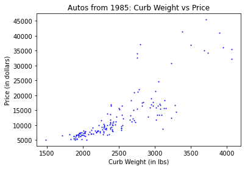

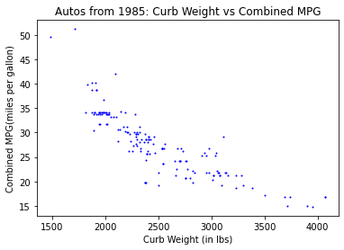

```python
#plotting scatter plot of curb weight against price
plt.scatter(df['curb-weight'], df['price'], s = 1, c = 'blue')

#setting the labels and title of graph
plt.title("Autos from 1985: Curb Weight vs Price")
plt.xlabel("Curb Weight (in lbs)")
plt.ylabel("Price (in dollars)")
plt.show()


#plotting scatter plot of curb weight against combined mpg
plt.scatter(df['curb-weight'], df['combined-mpg'], s = 1, c = 'blue')

#Setting the labels and title of graph
plt.title("Autos from 1985: Curb Weight vs Combined MPG")
plt.xlabel("Curb Weight (in lbs)")
plt.ylabel("Combined MPG(miles per gallon)")
plt.show()
```

After plotting the curb weights against price and combined mpg for each vehicle in the dataset, we can see a rough relationship for both.

For weight versus price, we can see a rough positive linear relationship. As the weight of a vehicle increases, so does the price as well. The data is more clustered and tight on the left-hand side (as vehicles from the 1980's were often not very heavy) and becomes more spread out as we move towards the right-hand side.

For weight versus combined mpg, we can see a decently well defined negative linear relationship. As the weight of a vehicle increases, the combined mpg tends to decrease. The data is more clustered in the middle-left of the chart, but in general, the data has a decently tight clustering to it and we can easily define a linear pattern through the center of the data.

##### Correlation Statistics:

Since we can see a decently well defined relationship between curb weight and the two dependent variables that we put it against, let's find the correlation values.

```python
print("Correlation Between Curb Weight and Price:")
print(df['curb-weight'].corr(df['price']))

print("Correlation Between Curb Weight and Combined MPG:")
print(df['curb-weight'].corr(df['combined-mpg']))
```

```
Correlation Between Curb Weight and Price:
0.8311263771848973
Correlation Between Curb Weight and Combined MPG:
-0.8619793555843024
```

#### Independent Variable: Number of Cylinders

I will now analyze the number of cylinders in the engines of the vehicles and how they affect the horsepower, prices, and combined mpgs of said vehicles.

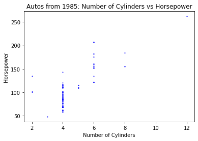

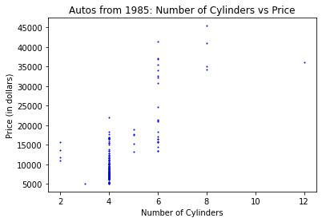

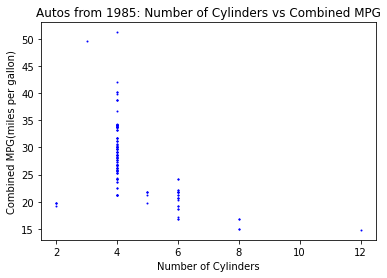

```python
#plotting scatter plot of number of cylinders against horsepower
plt.scatter(df['num-of-cylinders'], df['horsepower'], s = 1, c = 'blue')

#setting the labels and title of graph
plt.title("Autos from 1985: Number of Cylinders vs Horsepower")
plt.xlabel("Number of Cylinders")
plt.ylabel("Horsepower")
plt.show()


#plotting scatter plot of number of cylinders against price
plt.scatter(df['num-of-cylinders'], df['price'], s = 1, c = 'blue')

#setting the labels and title of graph
plt.title("Autos from 1985: Number of Cylinders vs Price")
plt.xlabel("Number of Cylinders")
plt.ylabel("Price (in dollars)")
plt.show()


#plotting scatter plot of number of cylinders against combined mpg
plt.scatter(df['num-of-cylinders'], df['combined-mpg'], s = 1, c = 'blue')

#setting the labels and title of graph
plt.title("Autos from 1985: Number of Cylinders vs Combined MPG")
plt.xlabel("Number of Cylinders")
plt.ylabel("Combined MPG(miles per gallon)")
plt.show()
```

After plotting the number of cylinders against horsepower, price, and combined mpg for each vehicle in the dataset, we can see a faint relationship for all three.

For both number of cylinders against horsepower and price, we can see a somewhat positive relationship. As the number of cylinders a vehicle's engine has increases, so does the horsepower and price of the vehicle.

For number of cylinders against combined mpg, we can instead see a more negative relationship. As the number of cylinders a vehicle's engine has increases, the fuel economy of the vehicle tends to decrease.

However, since most of the vehicles are clustered into the 4 or 6 cylinder categories, it is more difficult to draw any accurate conclusions regarding the correlation of number of cylinders with horsepower, price, and combined mpg. This dataset does not include enough entries for vehicles with 2, 3, 5, 8, or 12 cylinder engines. Therefore, we will move forward with our analysis without further considering the number of cylinders.

#### Independent Variable: Engine Size

I will now analyze the engine sizes of the vehicles and how they affect the horsepower, prices, and combined mpgs of said vehicles.

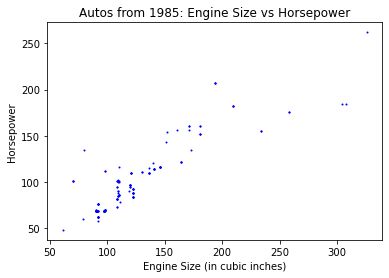

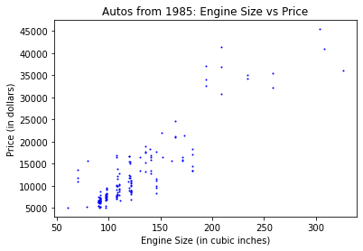

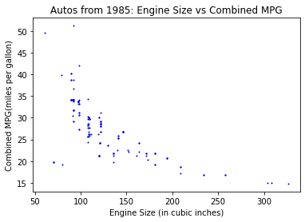

```python
#plotting scatter plot of engine size against horsepower
plt.scatter(df['engine-size'], df['horsepower'], s = 1, c = 'blue')

#setting the labels and title of graph
plt.title("Autos from 1985: Engine Size vs Horsepower")
plt.xlabel("Engine Size (in cubic inches)")
plt.ylabel("Horsepower")
plt.show()


#plotting scatter plot of engine size against price
plt.scatter(df['engine-size'], df['price'], s = 1, c = 'blue')

#setting the labels and title of graph
plt.title("Autos from 1985: Engine Size vs Price")
plt.xlabel("Engine Size (in cubic inches)")
plt.ylabel("Price (in dollars)")
plt.show()


#plotting scatter plot of engine size against combined mpg
plt.scatter(df['engine-size'], df['combined-mpg'], s = 1, c = 'blue')

#setting the labels and title of graph
plt.title("Autos from 1985: Engine Size vs Combined MPG")
plt.xlabel("Engine Size (in cubic inches)")
plt.ylabel("Combined MPG(miles per gallon)")
plt.show()
```

After plotting the engine size against horsepower, price, and combined mpg for each vehicle in the dataset, we can see significant relationships for all three.

For engine size versus horsepower and price, we can see a rough positive linear relationship. As the size of a vehicle's engine increases, the horsepower and price tend to as well. The data is more clustered towards the left-hand side (as most vehicles from this era, and in general, tend to have smaller engines rather than bigger) and becomes more spread out as we move towards the right-hand side.

For engine size versus combined mpg, we can see a significant negative relationship that curves as we move towards the right. As the size of a vehicle's engine increases, the fuel economy tends to decrease. The data is a bit more clustered in the left-hand size of the chart, but in general, the data has a very obvious pattern that clearly defines the relationship.

##### Correlation Statistics:

Since we can see a decently well defined relationship between engine size and the three dependent variables that we put it against, let's find the correlation values.

```python
print("Correlation Between Engine Size and Horsepower:")
print(df['engine-size'].corr(df['horsepower']))

print("Correlation Between Engine Size and Price:")
print(df['engine-size'].corr(df['price']))

print("Correlation Between Engine Size and Combined MPG:")
print(df['engine-size'].corr(df['combined-mpg']))
```

```
Correlation Between Engine Size and Horsepower:
0.8896486662780778
Correlation Between Engine Size and Price:
0.8885466228234518
Correlation Between Engine Size and Combined MPG:
-0.7145198017141546
```

## Part 4: Hypothesis Testing

### Creating a Hypothesis

#### Does the engine size affect horsepower, mpg, or cost?

Yes, the correlation between engine size and the three dependent variables does seem to be relatively strong. We were able to see a relationship in the analysis of the data where when engine size increased, horsepower and price increased as well, but the mpg of the vehicle decreased.

#### Does the number of cylinders affect horsepower, mpg, or cost?

Yes, there does seem to be a correlation between the number of cylinders a vehicle's engine has. Based on the limited data that we have from the dataset, vehicles with more cylinders tend to have higher horsepower and prices, along with lower mpg. However, since our dataset is filled mostly with 4 and 6 cylinder vehicles and is lacking in our cylinder possibilities, continuing analysis on the effect of number of cylinders is a bit unreliable.

#### Does the vehicle curb weight affect mpg or cost?

Yes, the curb weight of a vehicle does seem to heavily affect both the mpg and price of it. As a vehicle becomes heavier, it typically also becomes more expensive, along with lower mpg. I did not include horsepower in this analysis as it does not make sense that the weight of a vehicle would change how much horsepower its engine puts out. Larger vehicles tend to have more horsepower, so that they do not become too slow, but it is not simply because they are heavier that they will have more horsepower.

### Analyzing Correlation

I will proceed by analyzing the p-values and r-squared values of each of my hypotheses/claims. I will be moving forward with the following combinations:

- Engine Size : Horsepower
- Engine Size : MPG
- Engine Size : Cost
- Curb Weight : MPG
- Curb Weight : Cost

Based on these calculations, we can determine if we can reject the null hypotheses of no relationship (determined by p-value) and how much the variance in the dependent variables can be explained by the independent variables (determined by r-square value).

```python
lrm = stats.OLS(df['horsepower'], df['engine-size']).fit()
print("Summary:")
print(lrm.summary())
```

```
Summary:
                                 OLS Regression Results
=======================================================================================
Dep. Variable:             horsepower   R-squared (uncentered):                   0.974
Model:                            OLS   Adj. R-squared (uncentered):              0.974
Method:                 Least Squares   F-statistic:                              5907.
Date:                Wed, 11 May 2022   Prob (F-statistic):                   2.56e-125
Time:                        00:22:59   Log-Likelihood:                         -664.96
No. Observations:                 156   AIC:                                      1332.
Df Residuals:                     155   BIC:                                      1335.
Df Model:                           1
Covariance Type:            nonrobust
===============================================================================
                  coef    std err          t      P>|t|      [0.025      0.975]
-------------------------------------------------------------------------------
engine-size     0.7972      0.010     76.859      0.000       0.777       0.818
==============================================================================
Omnibus:                       34.517   Durbin-Watson:                   0.756
Prob(Omnibus):                  0.000   Jarque-Bera (JB):              121.808
Skew:                           0.764   Prob(JB):                     3.55e-27
Kurtosis:                       7.050   Cond. No.                         1.00
==============================================================================

Notes:
[1] R² is computed without centering (uncentered) since the model does not contain a constant.
[2] Standard Errors assume that the covariance matrix of the errors is correctly specified.
```

From the summary, we can see that our r-squared score is 0.974, which is very high, and our p-value score is 0.0, which is statistically significant. This means that we can reject the null hypothesis of no relationship, as well as see high correlation between the two variables.

```python
lrm = stats.OLS(df['combined-mpg'], df['engine-size']).fit()
print("Summary:")
print(lrm.summary())
```

```
Summary:
                                 OLS Regression Results
=======================================================================================
Dep. Variable:           combined-mpg   R-squared (uncentered):                   0.747
Model:                            OLS   Adj. R-squared (uncentered):              0.746
Method:                 Least Squares   F-statistic:                              458.6
Date:                Wed, 11 May 2022   Prob (F-statistic):                    3.63e-48
Time:                        00:23:00   Log-Likelihood:                         -636.82
No. Observations:                 156   AIC:                                      1276.
Df Residuals:                     155   BIC:                                      1279.
Df Model:                           1
Covariance Type:            nonrobust
===============================================================================
                  coef    std err          t      P>|t|      [0.025      0.975]
-------------------------------------------------------------------------------
engine-size     0.1855      0.009     21.414      0.000       0.168       0.203
==============================================================================
Omnibus:                       34.998   Durbin-Watson:                   0.631
Prob(Omnibus):                  0.000   Jarque-Bera (JB):               59.034
Skew:                          -1.100   Prob(JB):                     1.52e-13
Kurtosis:                       5.060   Cond. No.                         1.00
==============================================================================

Notes:
[1] R² is computed without centering (uncentered) since the model does not contain a constant.
[2] Standard Errors assume that the covariance matrix of the errors is correctly specified.
```

From the summary, we can see that our r-squared score is 0.747, which is relatively high, and our p-value score is 0.0, which is statistically significant. This means that we can reject the null hypothesis of no relationship, as well as see decently high correlation between the two variables.

```python
lrm = stats.OLS(df['price'], df['engine-size']).fit()
print("Summary:")
print(lrm.summary())
```

```
Summary:
                                 OLS Regression Results
=======================================================================================
Dep. Variable:                  price   R-squared (uncentered):                   0.906
Model:                            OLS   Adj. R-squared (uncentered):              0.906
Method:                 Least Squares   F-statistic:                              1499.
Date:                Wed, 11 May 2022   Prob (F-statistic):                    1.40e-81
Time:                        00:23:00   Log-Likelihood:                         -1538.5
No. Observations:                 156   AIC:                                      3079.
Df Residuals:                     155   BIC:                                      3082.
Df Model:                           1
Covariance Type:            nonrobust
===============================================================================
                  coef    std err          t      P>|t|      [0.025      0.975]
-------------------------------------------------------------------------------
engine-size   108.5820      2.805     38.713      0.000     103.042     114.123
==============================================================================
Omnibus:                       65.732   Durbin-Watson:                   0.589
Prob(Omnibus):                  0.000   Jarque-Bera (JB):              165.267
Skew:                           1.814   Prob(JB):                     1.30e-36
Kurtosis:                       6.502   Cond. No.                         1.00
==============================================================================

Notes:
[1] R² is computed without centering (uncentered) since the model does not contain a constant.
[2] Standard Errors assume that the covariance matrix of the errors is correctly specified.
```

From the summary, we can see that our r-squared score is 0.906, which is very high, and our p-value score is 0.0, which is statistically significant. This means that we can reject the null hypothesis of no relationship, as well as see high correlation between the two variables.

```python
lrm = stats.OLS(df['combined-mpg'], df['curb-weight']).fit()
print("Summary:")
print(lrm.summary())
```

```
Summary:
                                 OLS Regression Results
=======================================================================================
Dep. Variable:           combined-mpg   R-squared (uncentered):                   0.840
Model:                            OLS   Adj. R-squared (uncentered):              0.839
Method:                 Least Squares   F-statistic:                              811.4
Date:                Wed, 11 May 2022   Prob (F-statistic):                    1.75e-63
Time:                        00:23:01   Log-Likelihood:                         -601.39
No. Observations:                 156   AIC:                                      1205.
Df Residuals:                     155   BIC:                                      1208.
Df Model:                           1
Covariance Type:            nonrobust
===============================================================================
                  coef    std err          t      P>|t|      [0.025      0.975]
-------------------------------------------------------------------------------
curb-weight     0.0103      0.000     28.485      0.000       0.010       0.011
==============================================================================
Omnibus:                        1.457   Durbin-Watson:                   0.680
Prob(Omnibus):                  0.483   Jarque-Bera (JB):                1.138
Skew:                          -0.199   Prob(JB):                        0.566
Kurtosis:                       3.128   Cond. No.                         1.00
==============================================================================

Notes:
[1] R² is computed without centering (uncentered) since the model does not contain a constant.
[2] Standard Errors assume that the covariance matrix of the errors is correctly specified.
```

From the summary, we can see that our r-squared score is 0.840, which is very high, and our p-value score is 0.0, which is statistically significant. This means that we can reject the null hypothesis of no relationship, as well as see high correlation between the two variables.

```python
lrm = stats.OLS(df['price'], df['curb-weight']).fit()
print("Summary:")
print(lrm.summary())
```

```
Summary:
                                 OLS Regression Results
=======================================================================================
Dep. Variable:                  price   R-squared (uncentered):                   0.831
Model:                            OLS   Adj. R-squared (uncentered):              0.830
Method:                 Least Squares   F-statistic:                              762.8
Date:                Wed, 11 May 2022   Prob (F-statistic):                    9.59e-62
Time:                        00:23:01   Log-Likelihood:                         -1584.5
No. Observations:                 156   AIC:                                      3171.
Df Residuals:                     155   BIC:                                      3174.
Df Model:                           1
Covariance Type:            nonrobust
===============================================================================
                  coef    std err          t      P>|t|      [0.025      0.975]
-------------------------------------------------------------------------------
curb-weight     5.4537      0.197     27.620      0.000       5.064       5.844
==============================================================================
Omnibus:                       90.724   Durbin-Watson:                   0.586
Prob(Omnibus):                  0.000   Jarque-Bera (JB):              330.949
Skew:                           2.382   Prob(JB):                     1.37e-72
Kurtosis:                       8.313   Cond. No.                         1.00
==============================================================================

Notes:
[1] R² is computed without centering (uncentered) since the model does not contain a constant.
[2] Standard Errors assume that the covariance matrix of the errors is correctly specified.
```

From the summary, we can see that our r-squared score is 0.831, which is very high, and our p-value score is 0.0, which is statistically significant. This means that we can reject the null hypothesis of no relationship, as well as see high correlation between the two variables.

### Creating Predictive Linear Regression Models

Since every combination of variables in the previous section was proven to have significant correlations through p-values and r-squared values, we will move forward with creating models that can predict results for each using Linear Regression. Linear Regression is a good choice because it makes our estimation and predictive process simple and straightforward, while also creating models that are easy to plot and understand.

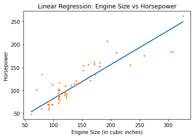

```python
#Linear Regression Model for Engine Size vs. Horsepower
fig, ax = plt.subplots()

#Finding polynomial for linear regression line and plotting
m, b = np.polyfit(df['engine-size'], df['horsepower'], 1)
poly = (m * df['engine-size']) + b
ax.plot(df['engine-size'], poly)

#Plotting individual data points for each vehicle
ax.plot(df['engine-size'], df['horsepower'], ms=2, linestyle='', marker='o')

#Setting the labels, title, and legend of graph
ax.set_xlabel("Engine Size (in cubic inches)")
ax.set_ylabel("Horsepower")
ax.set_title("Linear Regression: Engine Size vs Horsepower")
plt.show()
```

[figure not shown]

```python
#Linear Regression Model for Engine Size vs. Combined MPG
fig, ax = plt.subplots()

#Finding polynomial for linear regression line and plotting
m, b = np.polyfit(df['engine-size'], df['combined-mpg'], 1)
poly = (m * df['engine-size']) + b
ax.plot(df['engine-size'], poly)

#Plotting individual data points for each vehicle
ax.plot(df['engine-size'], df['combined-mpg'], ms=2, linestyle='', marker='o')

#Setting the labels, title, and legend of graph
ax.set_xlabel("Engine Size (in cubic inches)")
ax.set_ylabel("Combined MPG (miles per gallon)")
ax.set_title("Linear Regression: Engine Size vs Combined MPG")
plt.show()
```

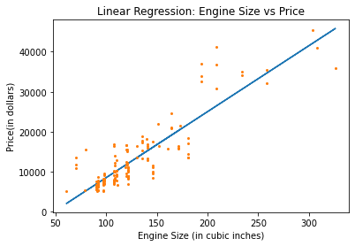

```python
#Linear Regression Model for Engine Size vs. Price
fig, ax = plt.subplots()

#Finding polynomial for linear regression line and plotting
m, b = np.polyfit(df['engine-size'], df['price'], 1)
poly = (m * df['engine-size']) + b
ax.plot(df['engine-size'], poly)

#Plotting individual data points for each vehicle
ax.plot(df['engine-size'], df['price'], ms=2, linestyle='', marker='o')

#Setting the labels, title, and legend of graph
ax.set_xlabel("Engine Size (in cubic inches)")
ax.set_ylabel("Price (in dollars)")
ax.set_title("Linear Regression: Engine Size vs Price")
plt.show()
```

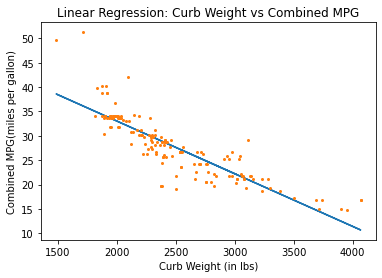

```python
#Linear Regression Model for Curb Weight vs. Combined MPG
fig, ax = plt.subplots()

#Finding polynomial for linear regression line and plotting
m, b = np.polyfit(df['curb-weight'], df['combined-mpg'], 1)
poly = (m * df['curb-weight']) + b
ax.plot(df['curb-weight'], poly)

#Plotting individual data points for each vehicle
ax.plot(df['curb-weight'], df['combined-mpg'], ms=2, linestyle='', marker='o')

#Setting the labels, title, and legend of graph
ax.set_xlabel("Curb Weight (in lbs)")
ax.set_ylabel("Combined MPG(miles per gallon)")
ax.set_title("Linear Regression: Curb Weight vs Combined MPG")
plt.show()
```

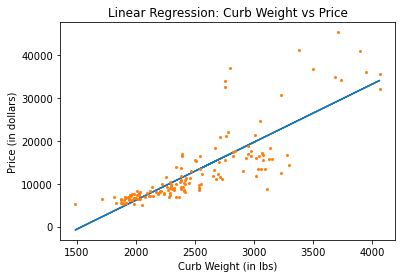

```python
#Linear Regression Model for Curb Weight vs. Price
fig, ax = plt.subplots()

#Finding polynomial for linear regression line and plotting
m, b = np.polyfit(df['curb-weight'], df['price'], 1)
poly = (m * df['curb-weight']) + b
ax.plot(df['curb-weight'], poly)

#Plotting individual data points for each vehicle
ax.plot(df['curb-weight'], df['price'], ms=2, linestyle='', marker='o')

#Setting the labels, title, and legend of graph
ax.set_xlabel("Curb Weight (in lbs)")
ax.set_ylabel("Price (in dollars)")
ax.set_title("Linear Regression: Curb Weight vs Price")
plt.show()
```

## Part 5: Insights and Takeaways

### What Went Well

Fortunately, the dataset was large enough that I was able to create and accurately test several different hypotheses, yet small enough to be easily manageable. Each of the five hypotheses that I created each ended up having high r-squared scores and low p-values, meaning that I could create linear regression models for each one. Furthermore, the linear regression models displayed above all look to accurately represent each of the five relationships. I believe that they each will do a decent job of predicting the respective result with decent accuracy. Furthermore, the dataset was very easy to import and clean up. All that needed to be done was to remove entries with missing data, remove columns that were not needed, and to adjust the variable types of a few columns.

### What Could Be Better

Some sections of the dataset were a bit lacking. For example, I was not able to continue with the analysis of the independent variable, number of cylinders, because of the lack of variation in the data for that category. There was a huge number of vehicles with 4 and 6 cylinder engines, but engines with 2, 3, 5, 8, and 12 cylinders were very sparse in numbers. This is likely due to the fact that micro-cars and exotic cars are not made in nearly as large numbers as economy and family vehicles. In general, the dataset could be improved simply with more vehicles. Something like 1000 entries instead of the ~160 that I used would have been beneficial. However, this might be difficult to obtain since the dataset set only includes unique consumer vehicles currently in production. There are less than 50 car manufacturers currently selling in the US and Toyota, one of the largest brands, sells roughly ~20 unqiue car models. However, if we include different variations of each model, such as hybrid/electric variations as well as different engine configurations, it may be easier to obtain a larger dataset, especially if we use a dataset from 2022 instead of 1985.

### Final Conclusions

To answer my originally posted question, "How does engine size, number of cylinders, and vehicle curb weight affect horsepower, mpg, and cost?", I can confidently answer that increases in engine size and vehicle curb weights lead to lower mpg figures and higher costs, with larger engines typically having more horsepower as well. As stated before, I cannot make clear conclusions about the effects of the number of cylinders due to lack of data. I believe that my linear regression models created above help us to visualize decently well the effects of engine size and vehicle curb weight, as well as predict a reasonably accurate value.

### Resources

1985 Vehicle Dataset: https://www.kaggle.com/datasets/toramky/automobile-dataset

Good Website for finding and exploring other datasets on your own: https://www.kaggle.com/

What is Linear Regression and How Does it Work?: https://machinelearningmastery.com/linear-regression-for-machine-learning/

Documentation for MatPlotLib: https://matplotlib.org/stable/index.html

Documentation for Pandas: https://pandas.pydata.org/pandas-docs/stable/

Documentation for NumPy: https://numpy.org/doc/